# 머신러닝을 이용한 당뇨병 예측

Jae Kwan Koo

```r
# install.packages("webshot")
# webshot::install_phantomjs()
```

### Introduction.

당뇨병에 영향을 주는 8가지 특징을 바탕으로, 기초적인 데이터분석과 통계학습을 통해 당뇨병을 예측하자.

| 변수 | 설명 |
| --- | --- |
| preg | 임신횟수 |
| plas | 혈장 포도당 농도 |
| pres | 혈압 |
| skin | 피부 주름 두께 |
| insu | 2시간 혈청 인슐린 |
| mass | weight / (height)^2 |
| pedi | 당뇨병 혈통 기능 |
| age | 나이 |
| class | 당뇨병 여부 |

### Library

```r
# data wrangling
library(data.table)
library(tidyverse)


# data assessment/visualizations
library(DT)
library(corrplot)
library(knitr)
library(plotly)
library(patchwork)

# model
library(caret)
library(doParallel)    # parallel in caret
library(rpart)         # making decision tree
library(rpart.plot)    # plot for decision tree
library(randomForest)  # using randomForest algorithm
library(pROC)          # using roc function in package
library(mice)          # (multiple imputation, MI)
library(xgboost)
```

### parallel process in caret

```r
no_cores <- detectCores()-1
cl <- makePSOCKcluster(no_cores)
registerDoParallel(cl)


## When you are done:
# stopCluster(cl)
```

### Import the Data

```r
data <- fread("dataset_37_diabetes.csv")
```

## Data manipulate

|  | preg | plas | pres | skin | insu | mass | pedi | age | class |
| --- | --- | --- | --- | --- | --- | --- | --- | --- | --- |
| 1 | 6 | 148 | 72 | 35 | 0 | 33.6 | 0.627 | 50 | tested_positive |
| 2 | 1 | 85 | 66 | 29 | 0 | 26.6 | 0.351 | 31 | tested_negative |
| 3 | 8 | 183 | 64 | 0 | 0 | 23.3 | 0.672 | 32 | tested_positive |
| 4 | 1 | 89 | 66 | 23 | 94 | 28.1 | 0.167 | 21 | tested_negative |
| 5 | 0 | 137 | 40 | 35 | 168 | 43.1 | 2.288 | 33 | tested_positive |
| 6 | 5 | 116 | 74 | 0 | 0 | 25.6 | 0.201 | 30 | tested_negative |
| 7 | 3 | 78 | 50 | 32 | 88 | 31 | 0.248 | 26 | tested_positive |
| 8 | 10 | 115 | 0 | 0 | 0 | 35.3 | 0.134 | 29 | tested_negative |
| 9 | 2 | 197 | 70 | 45 | 543 | 30.5 | 0.158 | 53 | tested_positive |
| 10 | 8 | 125 | 96 | 0 | 0 | 0 | 0.232 | 54 | tested_positive |

[output cut: 758 more lines]

```r
summary(data); str(data)
```

```
##       preg             plas            pres             skin
##  Min.   : 0.000   Min.   :  0.0   Min.   :  0.00   Min.   : 0.00
##  1st Qu.: 1.000   1st Qu.: 99.0   1st Qu.: 62.00   1st Qu.: 0.00
##  Median : 3.000   Median :117.0   Median : 72.00   Median :23.00
##  Mean   : 3.845   Mean   :120.9   Mean   : 69.11   Mean   :20.54
##  3rd Qu.: 6.000   3rd Qu.:140.2   3rd Qu.: 80.00   3rd Qu.:32.00
##  Max.   :17.000   Max.   :199.0   Max.   :122.00   Max.   :99.00
##       insu            mass            pedi             age
##  Min.   :  0.0   Min.   : 0.00   Min.   :0.0780   Min.   :21.00
##  1st Qu.:  0.0   1st Qu.:27.30   1st Qu.:0.2437   1st Qu.:24.00
##  Median : 30.5   Median :32.00   Median :0.3725   Median :29.00
##  Mean   : 79.8   Mean   :31.99   Mean   :0.4719   Mean   :33.24
##  3rd Qu.:127.2   3rd Qu.:36.60   3rd Qu.:0.6262   3rd Qu.:41.00
##  Max.   :846.0   Max.   :67.10   Max.   :2.4200   Max.   :81.00
##     class
##  Length:768
##  Class :character
##  Mode  :character
##
##
##
```

```
## Classes 'data.table' and 'data.frame':   768 obs. of  9 variables:
##  $ preg : int  6 1 8 1 0 5 3 10 2 8 ...
##  $ plas : int  148 85 183 89 137 116 78 115 197 125 ...
##  $ pres : int  72 66 64 66 40 74 50 0 70 96 ...
##  $ skin : int  35 29 0 23 35 0 32 0 45 0 ...
##  $ insu : int  0 0 0 94 168 0 88 0 543 0 ...
##  $ mass : num  33.6 26.6 23.3 28.1 43.1 25.6 31 35.3 30.5 0 ...
##  $ pedi : num  0.627 0.351 0.672 0.167 2.288 ...
##  $ age  : int  50 31 32 21 33 30 26 29 53 54 ...
##  $ class: chr  "tested_positive" "tested_negative" "tested_positive" "tested_negative" ...
##  - attr(*, ".internal.selfref")=<externalptr>
```

```r
data$class<-as.factor(data$class)
```

### Handling the Missing Values.

```r
sapply(data,function(x) sum(is.na(x)))
```

```
##  preg  plas  pres  skin  insu  mass  pedi   age class
##     0     0     0     0     0     0     0     0     0
```

```r
sapply(data,function(x) sum(x==0))
```

```
##  preg  plas  pres  skin  insu  mass  pedi   age class
##   111     5    35   227   374    11     0     0     0
```

결측치는 없고 0의 수치를 가진 데이터들이 많이 존재함을 일단 알 수 있다. preg를 제외한 변수들은 0을 가진다는 것이 말이 되지 않으므로 이 수치를 어떻게 대체할지 생각해보자.

```r
data<-data %>% mutate(plas=replace(plas, list=(plas==0), NA),
                      pres=replace(pres, list=(pres==0), NA),
                      skin=replace(skin, list=(skin==0), NA),
                      insu=replace(insu, list=(insu==0), NA),
                      mass=replace(mass, list=(mass==0), NA))


# dataset을 m개 만든다. 디폴트는 5 , method : randomforest
miceMod <- mice(data, method="rf",seed = 1234, print=F, m = 5)


miceOutput <- complete(miceMod, 1)
datatable(miceOutput)
```

|  | preg | plas | pres | skin | insu | mass | pedi | age | class |
| --- | --- | --- | --- | --- | --- | --- | --- | --- | --- |
| 1 | 6 | 148 | 72 | 35 | 130 | 33.6 | 0.627 | 50 | tested_positive |
| 2 | 1 | 85 | 66 | 29 | 41 | 26.6 | 0.351 | 31 | tested_negative |
| 3 | 8 | 183 | 64 | 28 | 96 | 23.3 | 0.672 | 32 | tested_positive |
| 4 | 1 | 89 | 66 | 23 | 94 | 28.1 | 0.167 | 21 | tested_negative |
| 5 | 0 | 137 | 40 | 35 | 168 | 43.1 | 2.288 | 33 | tested_positive |
| 6 | 5 | 116 | 74 | 17 | 110 | 25.6 | 0.201 | 30 | tested_negative |
| 7 | 3 | 78 | 50 | 32 | 88 | 31 | 0.248 | 26 | tested_positive |
| 8 | 10 | 115 | 70 | 33 | 105 | 35.3 | 0.134 | 29 | tested_negative |
| 9 | 2 | 197 | 70 | 45 | 543 | 30.5 | 0.158 | 53 | tested_positive |
| 10 | 8 | 125 | 96 | 32 | 54 | 30.3 | 0.232 | 54 | tested_positive |

[output cut: 758 more lines]

complete함수를 통해 결측값에 대해 채워진 dataframe을 재지정.  
이 채워진 데이터들에 대해 회귀분석을 해보자.

```r
fit <- with(miceMod,lm(preg~plas+pres+skin+insu+mass+pedi+age+class))

pool_fit <- pool(fit)
summary(pool_fit)
```

```
##                   term     estimate   std.error  statistic        df
## 1          (Intercept) -0.745298538 0.806142133 -0.9245250 403.52146
## 2                 plas -0.005215451 0.004551946 -1.1457630 260.01029
## 3                 pres  0.009351285 0.009859817  0.9484238 153.99592
## 4                 skin  0.012187136 0.016847456  0.7233814  17.69597
## 5                 insu -0.001779030 0.001230901 -1.4453076  30.61109
## 6                 mass -0.018239665 0.021374400 -0.8533416 113.23089
## 7                 pedi -0.614426175 0.314260299 -1.9551505 731.67187
## 8                  age  0.150262768 0.009609915 15.6362222 709.69299
## 9 classtested_positive  1.030768243 0.255132313  4.0401321 745.24495
##        p.value
## 1 3.557656e-01
## 2 2.529466e-01
## 3 3.443997e-01
## 4 4.788993e-01
## 5 1.585320e-01
## 6 3.952715e-01
## 7 5.094566e-02
## 8 0.000000e+00
## 9 5.896291e-05
```

```r
anyNA(miceOutput)
```

```
## [1] FALSE
```

```r
str(miceOutput)
```

```
## 'data.frame':    768 obs. of  9 variables:
##  $ preg : int  6 1 8 1 0 5 3 10 2 8 ...
##  $ plas : int  148 85 183 89 137 116 78 115 197 125 ...
##  $ pres : int  72 66 64 66 40 74 50 70 70 96 ...
##  $ skin : int  35 29 28 23 35 17 32 33 45 32 ...
##  $ insu : int  130 41 96 94 168 110 88 105 543 54 ...
##  $ mass : num  33.6 26.6 23.3 28.1 43.1 25.6 31 35.3 30.5 30.3 ...
##  $ pedi : num  0.627 0.351 0.672 0.167 2.288 ...
##  $ age  : int  50 31 32 21 33 30 26 29 53 54 ...
##  $ class: Factor w/ 2 levels "tested_negative",..: 2 1 2 1 2 1 2 1 2 2 ...
```

```r
data2 <- miceOutput  # not exist NA value in data
```

결측치는 없음을 확인했고, preg(임신횟수)를 제외한 나머지 변수에서 0은 일어날 수 없는 수치이므로 mice패키지를 이용하여 결측치를 채워넣었다.

- Refer

[mice1](https://rstudio-pubs-static.s3.amazonaws.com/192402_012091b9adac42dbbd22c4d07cb00d36.html)

[mice2](https://www.gerkovink.com/miceVignettes/Convergence_pooling/Convergence_and_pooling.html)

### making age group.

나이대에 대한 변수를 새로 만들었다.

```r
data2 %>% mutate(age_group=
                  case_when(age>=20 & age<30 ~ "20s",
                            age>=30 & age<40 ~ "30s",
                            age>=40 & age<50 ~ "40s",
                            age>=50 & age<60 ~ "50s",
                            age>=60 & age<70 ~ "60s",
                            age>=70 & age<80 ~ "70s",
                            age>=80 & age<90 ~ "80s")) %>%
  group_by(age_group) %>%
  summarise(n=n())
```

```
## # A tibble: 7 x 2
##   age_group     n
##   <chr>     <int>
## 1 20s         396
## 2 30s         165
## 3 40s         118
## 4 50s          57
## 5 60s          29
## 6 70s           2
## 7 80s           1
```

```r
# group_num <- data2 %>% mutate(age_group=
#                                 case_when(age>=20 & age<30 ~ "20s",
#                                           age>=30 & age<40 ~ "30s",
#                                           age>=40 & age<50 ~ "40s",
#                                           age>=50 & age<60 ~ "50s",
#                                           age>=60 ~ "60~")) %>%
#   group_by(age_group) %>%
#   summarise(number=n()) %>%
#   ggplot(aes(x=age_group,y=number))+geom_bar(stat="identity")+
#   theme_bw(base_size = 20,base_line_size = 0.5)
#
# ggplotly(group_num,session="knitr",width = 500, height = 500)
```

```r
mean_group <- data2 %>% mutate(age_group=
                            case_when(age>=20 & age<30 ~ "20s",
                            age>=30 & age<40 ~ "30s",
                            age>=40 & age<50 ~ "40s",
                            age>=50 & age<60 ~ "50s",
                            age>=60 ~ "60~")) %>% group_by(age_group) %>%
  summarise(mean(preg),mean(plas),mean(pres),mean(skin),mean(insu),mean(mass),mean(pedi))



knitr::kable(cbind(mean_group[,1],round(mean_group[,-1],3)))   # table form
```

| age_group | mean(preg) | mean(plas) | mean(pres) | mean(skin) | mean(insu) | mean(mass) | mean(pedi) |
| --- | --- | --- | --- | --- | --- | --- | --- |
| 20s | 1.922 | 114.470 | 68.801 | 27.561 | 139.972 | 32.004 | 0.451 |
| 30s | 4.988 | 126.230 | 73.679 | 29.679 | 165.830 | 32.621 | 0.528 |
| 40s | 7.051 | 126.093 | 77.314 | 31.907 | 168.534 | 34.618 | 0.443 |
| 50s | 6.596 | 140.281 | 79.807 | 28.070 | 209.035 | 31.870 | 0.529 |
| 60~ | 5.031 | 138.250 | 78.125 | 29.688 | 250.438 | 29.387 | 0.445 |

나이대별로 각 요인들의 평균치이다.

```r
data3 <- data2 %>% mutate(age_group=
                            case_when(age>=20 & age<30 ~ "20s",
                                      age>=30 & age<40 ~ "30s",
                                      age>=40 & age<50 ~ "40s",
                                      age>=50 & age<60 ~ "50s",
                                      age>=60 ~ "60~"))
```

age group변수를 추가한 data3를 이제 사용하겠다.

## EDA

### Box-Plot

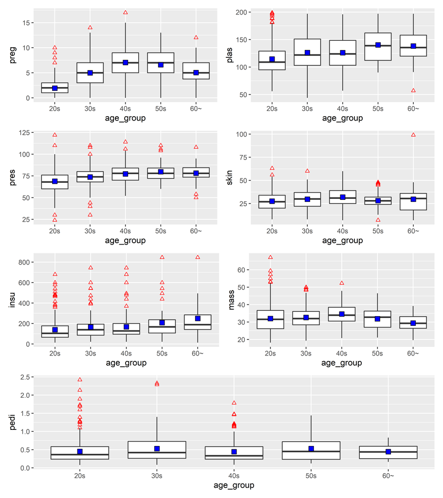

```r
p1 <-
data3[,!(names(data3) %in% c("class"))] %>% group_by(age_group) %>%
  ggplot(aes(x=age_group,y=preg))+ geom_boxplot(outlier.color = 'red',outlier.shape = 2)+
  stat_summary(fun="mean", geom="point", shape=22, size=3, fill="blue")

p2 <-
data3[,!(names(data3) %in% c("class"))] %>% group_by(age_group) %>%
  ggplot(aes(x=age_group,y=plas))+geom_boxplot(outlier.color = 'red',outlier.shape = 2)+
  stat_summary(fun="mean", geom="point", shape=22, size=3, fill="blue")

p3 <-
data3[,!(names(data3) %in% c("class"))] %>% group_by(age_group) %>%
  ggplot(aes(x=age_group,y=pres))+geom_boxplot(outlier.color = 'red',outlier.shape = 2)+
  stat_summary(fun="mean", geom="point", shape=22, size=3, fill="blue")

p4 <-
data3[,!(names(data3) %in% c("class"))] %>% group_by(age_group) %>%
  ggplot(aes(x=age_group,y=skin))+geom_boxplot(outlier.color = 'red',outlier.shape = 2)+
  stat_summary(fun="mean", geom="point", shape=22, size=3, fill="blue")

p5 <-
data3[,!(names(data3) %in% c("class"))] %>% group_by(age_group) %>%
  ggplot(aes(x=age_group,y=insu))+geom_boxplot(outlier.color = 'red',outlier.shape = 2)+
  stat_summary(fun="mean", geom="point", shape=22, size=3, fill="blue")

p6 <-
data3[,!(names(data3) %in% c("class"))] %>% group_by(age_group) %>%
  ggplot(aes(x=age_group,y=mass))+geom_boxplot(outlier.color = 'red',outlier.shape = 2)+
  stat_summary(fun="mean", geom="point", shape=22, size=3, fill="blue")

p7 <-
data3[,!(names(data3) %in% c("class"))] %>% group_by(age_group) %>%
  ggplot(aes(x=age_group,y=pedi))+geom_boxplot(outlier.color = 'red',outlier.shape = 2)+
  stat_summary(fun="mean", geom="point", shape=22, size=3, fill="blue")


(p1+p2) / (p3+p4) / (p5+p6) / p7
```

```r
# p1+p1+p3+p4+p5+p6+p7 + plot_layout(ncol=2)
```

### class_level variable

|  | preg | plas | pres | skin | insu | mass | pedi | age | class | age_group | class_level |
| --- | --- | --- | --- | --- | --- | --- | --- | --- | --- | --- | --- |
| 1 | 6 | 148 | 72 | 35 | 130 | 33.6 | 0.627 | 50 | tested_positive | 50s | 1 |
| 2 | 1 | 85 | 66 | 29 | 41 | 26.6 | 0.351 | 31 | tested_negative | 30s | 0 |
| 3 | 8 | 183 | 64 | 28 | 96 | 23.3 | 0.672 | 32 | tested_positive | 30s | 1 |
| 4 | 1 | 89 | 66 | 23 | 94 | 28.1 | 0.167 | 21 | tested_negative | 20s | 0 |
| 5 | 0 | 137 | 40 | 35 | 168 | 43.1 | 2.288 | 33 | tested_positive | 30s | 1 |
| 6 | 5 | 116 | 74 | 17 | 110 | 25.6 | 0.201 | 30 | tested_negative | 30s | 0 |
| 7 | 3 | 78 | 50 | 32 | 88 | 31 | 0.248 | 26 | tested_positive | 20s | 1 |
| 8 | 10 | 115 | 70 | 33 | 105 | 35.3 | 0.134 | 29 | tested_negative | 20s | 0 |
| 9 | 2 | 197 | 70 | 45 | 543 | 30.5 | 0.158 | 53 | tested_positive | 50s | 1 |
| 10 | 8 | 125 | 96 | 32 | 54 | 30.3 | 0.232 | 54 | tested_positive | 50s | 1 |

[output cut: 758 more lines]

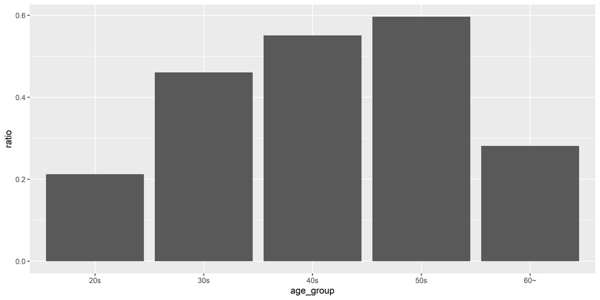

```r
data3 %>% group_by(age_group) %>%
  summarise(ratio=sum(class_level)/n()) %>%
  ggplot(aes(x=age_group,y=ratio))+geom_bar(stat="identity")
```

### Correlation Plot.

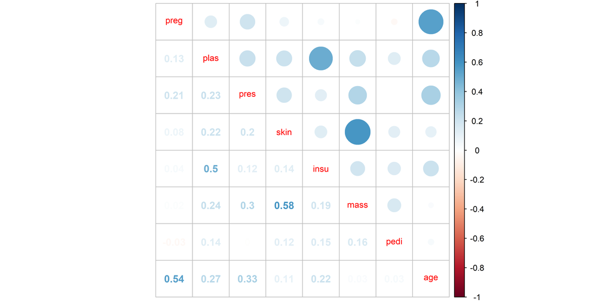

```r
data3 %>%
  select(-class, -age_group, -class_level) %>%
  select_if(is.numeric) %>%
  cor(use="complete.obs") %>%
  corrplot.mixed(tl.cex=0.85)
```

(preg, age) (plas, insu) (skin, mass) 변수들이 어느정도 상관관계를 보이고 있다.

## Machine Learning Algorithm.

```r
set.seed(1234)
index<-createDataPartition(data3$class,p=0.7,list=F)

train<-data3[index,]
test<-data3[-index,]
```

train과 test데이터를 70%확률로 랜덤하게 분리.

### Logistic Regression.

```r
str(data3)
```

```
## 'data.frame':    768 obs. of  11 variables:
##  $ preg       : int  6 1 8 1 0 5 3 10 2 8 ...
##  $ plas       : int  148 85 183 89 137 116 78 115 197 125 ...
##  $ pres       : int  72 66 64 66 40 74 50 70 70 96 ...
##  $ skin       : int  35 29 28 23 35 17 32 33 45 32 ...
##  $ insu       : int  130 41 96 94 168 110 88 105 543 54 ...
##  $ mass       : num  33.6 26.6 23.3 28.1 43.1 25.6 31 35.3 30.5 30.3 ...
##  $ pedi       : num  0.627 0.351 0.672 0.167 2.288 ...
##  $ age        : int  50 31 32 21 33 30 26 29 53 54 ...
##  $ class      : Factor w/ 2 levels "tested_negative",..: 2 1 2 1 2 1 2 1 2 2 ...
##  $ age_group  : chr  "50s" "30s" "30s" "20s" ...
##  $ class_level: num  1 0 1 0 1 0 1 0 1 1 ...
```

```r
set.seed(1234)

logistic_model<-glm(class~preg+plas+pres+skin+insu+mass+pedi+age,
                    data = train, family = "binomial")

summary(logistic_model)
```

```
##
## Call:
## glm(formula = class ~ preg + plas + pres + skin + insu + mass +
##     pedi + age, family = "binomial", data = train)
##
## Deviance Residuals:
##     Min       1Q   Median       3Q      Max
## -2.8096  -0.7208  -0.4134   0.7226   2.4232
##
## Coefficients:
##               Estimate Std. Error z value Pr(>|z|)
## (Intercept) -9.0920023  0.9498043  -9.573  < 2e-16 ***
## preg         0.0973060  0.0388095   2.507 0.012167 *
## plas         0.0382225  0.0046740   8.178 2.89e-16 ***
## pres        -0.0028609  0.0104634  -0.273 0.784534
## skin         0.0074268  0.0134063   0.554 0.579591
## insu        -0.0007037  0.0010110  -0.696 0.486437
## mass         0.0753888  0.0215427   3.500 0.000466 ***
## pedi         1.0284548  0.3435768   2.993 0.002759 **
## age          0.0120199  0.0115899   1.037 0.299690
## ---
## Signif. codes:  0 '***' 0.001 '**' 0.01 '*' 0.05 '.' 0.1 ' ' 1
##
## (Dispersion parameter for binomial family taken to be 1)
##
##     Null deviance: 696.28  on 537  degrees of freedom
## Residual deviance: 504.48  on 529  degrees of freedom
## AIC: 522.48
##
## Number of Fisher Scoring iterations: 5
```

```r
test$class_prob<-predict(logistic_model, test[,1:8],type = "response")

test$class_pred<-ifelse(test$class_prob>0.5,1,0)
```

response로 두어 link에 걸리는 y의 확률값을 계산

```r
mean(test$class_level==test$class_pred)
```

```
## [1] 0.7652174
```

```r
confusionMatrix(as.factor(test$class_pred), as.factor(test$class_level))
```

```
## Confusion Matrix and Statistics
##
##           Reference
## Prediction   0   1
##          0 129  33
##          1  21  47
##
##                Accuracy : 0.7652
##                  95% CI : (0.705, 0.8184)
##     No Information Rate : 0.6522
##     P-Value [Acc > NIR] : 0.0001394
##
##                   Kappa : 0.4637
##
##  Mcnemar's Test P-Value : 0.1344166
##
##             Sensitivity : 0.8600
##             Specificity : 0.5875
##          Pos Pred Value : 0.7963
##          Neg Pred Value : 0.6912
##              Prevalence : 0.6522
##          Detection Rate : 0.5609
##    Detection Prevalence : 0.7043
##       Balanced Accuracy : 0.7238
##
##        'Positive' Class : 0
##
```

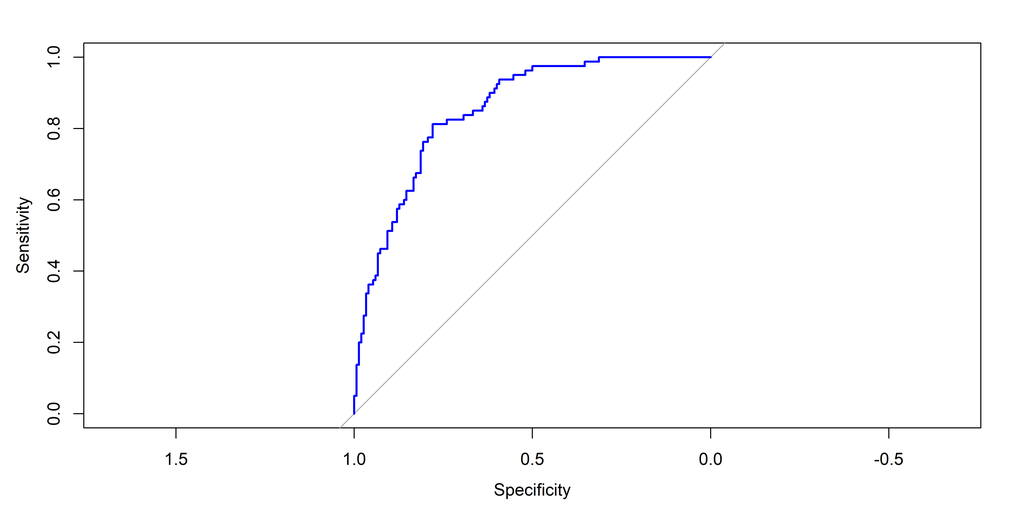

```r
# In this exercise you will create a ROC curve and compute the area under the curve (AUC) to evaluate the logistic regression model of class_level you built earlier.

ROC<-roc(test$class_level, test$class_prob)           # Create a ROC curve

plot(ROC,col="blue")                                  # Plot the ROC curve
```

```r
auc(ROC)                                              # Calculate the area under the curve (AUC)
```

```
## Area under the curve: 0.8533
```

The ROC curve shows the trade-off between sensitivity (or TPR) and specificity (1 – FPR). Classifiers that give curves closer to the top-left corner indicate a better performance.

- refer

[ROC1](https://nittaku.tistory.com/297)

[ROC2](https://www.displayr.com/what-is-a-roc-curve-how-to-interpret-it/)

### Decision Tree.

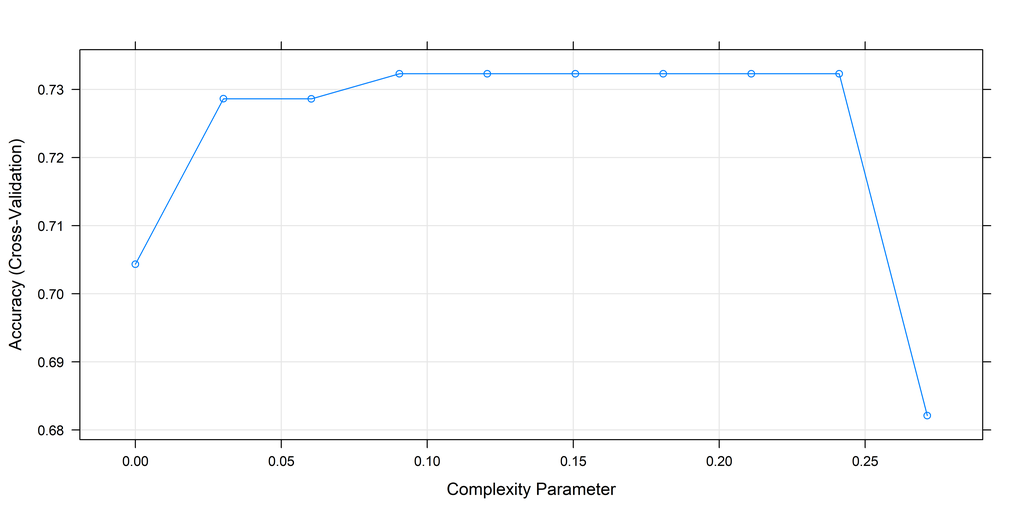

```r
# tree_model <- rpart(class~preg+plas+pres+skin+insu+mass+pedi+age, data = train, method = "class", control = rpart.control(cp = 0))
#
# tree_model

# Fit the model on the training set
set.seed(1234)

tree_model <- train(class~preg+plas+pres+skin+insu+mass+pedi+age,
                    data = train,
                    method = "rpart",
                    trControl = trainControl("cv", number = 5),
                    tuneLength = 10)

# Plot model accuracy vs different values of
# cp (complexity parameter)
plot(tree_model)
```

```r
# Print the best tuning parameter cp that
# maximizes the model accuracy
tree_model$bestTune
```

```
##          cp
## 9 0.2411348
```

```r
# Plot the final tree model
# par(xpd = NA) # Avoid clipping the text in some device
#
# plot(tree_model$finalModel)
# text(tree_model$finalModel,  digits = 3)
```

```r
# Decision rules in the model
tree_model$finalModel
```

```
## n= 538
##
## node), split, n, loss, yval, (yprob)
##       * denotes terminal node
##
## 1) root 538 188 tested_negative (0.6505576 0.3494424)
##   2) plas< 127.5 343  65 tested_negative (0.8104956 0.1895044) *
##   3) plas>=127.5 195  72 tested_positive (0.3692308 0.6307692) *
```

```r
prediction <- predict(tree_model, test[,1:8])

table(actual = test$class,pre=prediction); mean(prediction==test$class)
```

```
##                  pre
## actual            tested_negative tested_positive
##   tested_negative             113              37
##   tested_positive              27              53
```

```
## [1] 0.7217391
```

```r
confusionMatrix(prediction,test$class)
```

```
## Confusion Matrix and Statistics
##
##                  Reference
## Prediction        tested_negative tested_positive
##   tested_negative             113              27
##   tested_positive              37              53
##
##                Accuracy : 0.7217
##                  95% CI : (0.659, 0.7786)
##     No Information Rate : 0.6522
##     P-Value [Acc > NIR] : 0.0148
##
##                   Kappa : 0.404
##
##  Mcnemar's Test P-Value : 0.2606
##
##             Sensitivity : 0.7533
##             Specificity : 0.6625
##          Pos Pred Value : 0.8071
##          Neg Pred Value : 0.5889
##              Prevalence : 0.6522
##          Detection Rate : 0.4913
##    Detection Prevalence : 0.6087
##       Balanced Accuracy : 0.7079
##
##        'Positive' Class : tested_negative
##
```

```r
# Plot the model with default settings
# rpart.plot(tree_model)
```

```r
# cross-validation을 계산해 주는 함수로 print.cp를 제공,
# rpart패키지도 과적합화 문제가 있기 때문

# printcp(tree_model)
# plotcp(tree_model)
```

```r
# ptree <- prune(tree_model, cp= tree_model$cptable[which.min(tree_model$cptable[,"xerror"]),"CP"])
# plot(ptree)
# text(ptree)
```

```r
rpartpred <- predict(tree_model, test, type='raw')

confusionMatrix(rpartpred, test$class)
```

```
## Confusion Matrix and Statistics
##
##                  Reference
## Prediction        tested_negative tested_positive
##   tested_negative             113              27
##   tested_positive              37              53
##
##                Accuracy : 0.7217
##                  95% CI : (0.659, 0.7786)
##     No Information Rate : 0.6522
##     P-Value [Acc > NIR] : 0.0148
##
##                   Kappa : 0.404
##
##  Mcnemar's Test P-Value : 0.2606
##
##             Sensitivity : 0.7533
##             Specificity : 0.6625
##          Pos Pred Value : 0.8071
##          Neg Pred Value : 0.5889
##              Prevalence : 0.6522
##          Detection Rate : 0.4913
##    Detection Prevalence : 0.6087
##       Balanced Accuracy : 0.7079
##
##        'Positive' Class : tested_negative
##
```

### RandomForest

```r
set.seed(1234)

RandomForest_model <- randomForest(class~preg+plas+skin+insu+mass+pedi+age,
                                   data=train[,1:9],ntree=500,importance=T)

prediction2 <- predict(RandomForest_model, test[,1:8], type = "class")
mean(prediction2==test$class)
```

```
## [1] 0.7652174
```

```r
confusionMatrix(prediction2, test$class)
```

```
## Confusion Matrix and Statistics
##
##                  Reference
## Prediction        tested_negative tested_positive
##   tested_negative             128              32
##   tested_positive              22              48
##
##                Accuracy : 0.7652
##                  95% CI : (0.705, 0.8184)
##     No Information Rate : 0.6522
##     P-Value [Acc > NIR] : 0.0001394
##
##                   Kappa : 0.467
##
##  Mcnemar's Test P-Value : 0.2206714
##
##             Sensitivity : 0.8533
##             Specificity : 0.6000
##          Pos Pred Value : 0.8000
##          Neg Pred Value : 0.6857
##              Prevalence : 0.6522
##          Detection Rate : 0.5565
##    Detection Prevalence : 0.6957
##       Balanced Accuracy : 0.7267
##
##        'Positive' Class : tested_negative
##
```

```r
importance(RandomForest_model)
```

```
##      tested_negative tested_positive MeanDecreaseAccuracy MeanDecreaseGini
## preg        8.596011      -0.5850548             6.755758         19.42124
## plas       27.483739      29.2271165            38.665275         60.65558
## skin        3.637913       1.9065296             4.094452         23.19214
## insu        4.176434       8.0127404             8.761287         36.67510
## mass        6.903281      12.7484666            13.278428         37.67530
## pedi        4.148090       1.7110094             4.135606         32.43387
## age        10.206432       8.1552868            12.716586         33.86113
```

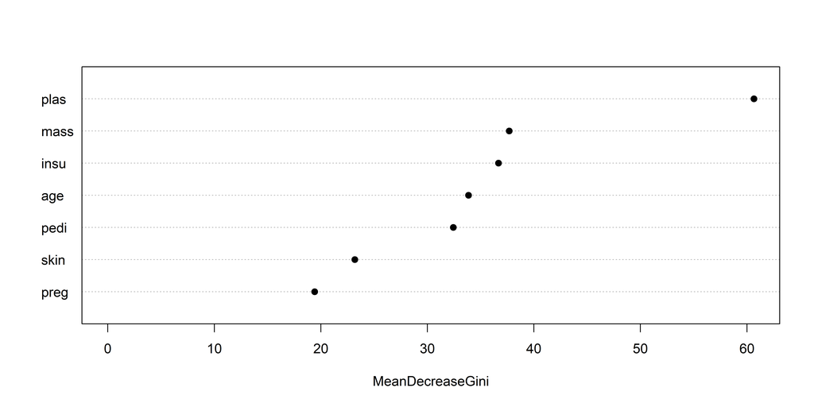

```r
varImpPlot(RandomForest_model, type=2, pch=19, col=1, cex=1, main="")
```

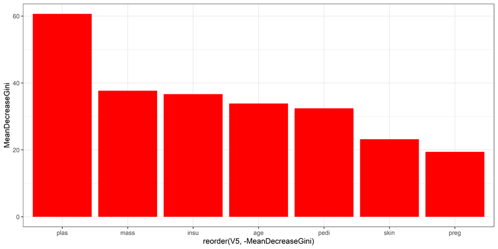

```r
importance_data <- data.frame(importance(RandomForest_model))
importance_data[,5] <- rownames(importance_data)

ggplot(data=importance_data,aes(x=reorder(V5,-MeanDecreaseGini),y=MeanDecreaseGini))+
  geom_bar(stat="identity",fill="red")+
  theme_bw()
```

변수의 중요도를 확인할 수 있다. 중요도가 낮은 하위 2개의 변수를 제외하고 다시 모델링을 해보자.

```r
set.seed(1234)

RandomForest_model2 <-
  randomForest(class~plas+insu+mass+pedi+age,
               data=train[,1:9], ntree=500, importance=T)

prediction3 <- predict(RandomForest_model2, test[,1:8], type = "class")


mean(prediction3==test$class)
```

```
## [1] 0.7869565
```

```r
confusionMatrix(prediction3, test$class)
```

```
## Confusion Matrix and Statistics
##
##                  Reference
## Prediction        tested_negative tested_positive
##   tested_negative             130              29
##   tested_positive              20              51
##
##                Accuracy : 0.787
##                  95% CI : (0.7283, 0.838)
##     No Information Rate : 0.6522
##     P-Value [Acc > NIR] : 5.84e-06
##
##                   Kappa : 0.5178
##
##  Mcnemar's Test P-Value : 0.2531
##
##             Sensitivity : 0.8667
##             Specificity : 0.6375
##          Pos Pred Value : 0.8176
##          Neg Pred Value : 0.7183
##              Prevalence : 0.6522
##          Detection Rate : 0.5652
##    Detection Prevalence : 0.6913
##       Balanced Accuracy : 0.7521
##
##        'Positive' Class : tested_negative
##
```

성능이 개선된 것을 확인할 수 있다.

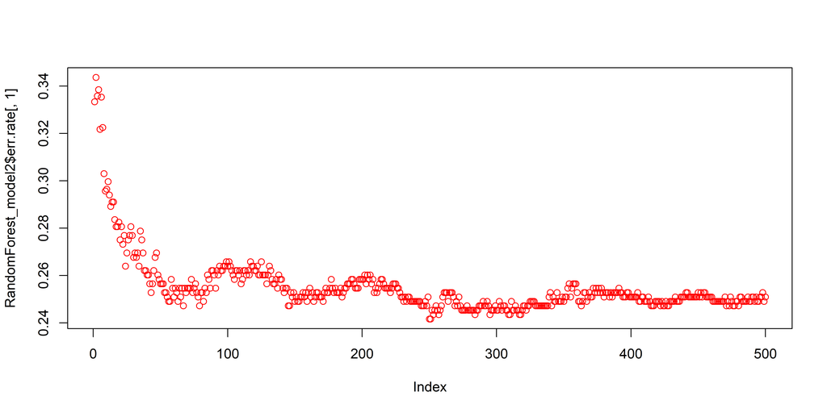

```r
plot(RandomForest_model2$err.rate[,1], col='red')
```

#### Random forest with cross validation in caret

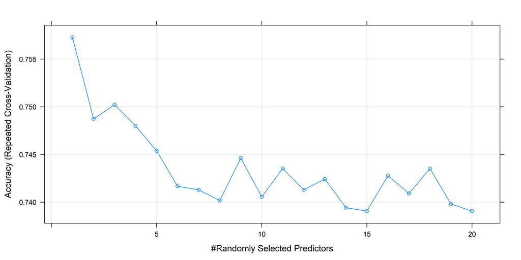

```r
control <- trainControl(method="repeatedcv",
                        number = 10,
                        repeats = 5,
                        index = createMultiFolds(train$class, k=5,
                                                 times = 5))

customGrid <- expand.grid(mtry = 1:20)



rf <- train(x = train[,1:8], y = train$class,
            method = "rf",
            importance=TRUE,
            trControl = control,
            tuneGrid = customGrid,
            verbose = F,
            preProcess = c("center", "scale"))


plot(rf)
```

```r
pre <- predict(rf, test[,1:8])

confusionMatrix(pre, test$class)
```

```
## Confusion Matrix and Statistics
##
##                  Reference
## Prediction        tested_negative tested_positive
##   tested_negative             134              34
##   tested_positive              16              46
##
##                Accuracy : 0.7826
##                  95% CI : (0.7236, 0.8341)
##     No Information Rate : 0.6522
##     P-Value [Acc > NIR] : 1.156e-05
##
##                   Kappa : 0.4943
##
##  Mcnemar's Test P-Value : 0.01621
##
##             Sensitivity : 0.8933
##             Specificity : 0.5750
##          Pos Pred Value : 0.7976
##          Neg Pred Value : 0.7419
##              Prevalence : 0.6522
##          Detection Rate : 0.5826
##    Detection Prevalence : 0.7304
##       Balanced Accuracy : 0.7342
##
##        'Positive' Class : tested_negative
##
```

### XGBOOST

```r
input_x <- as.matrix(train[,1:8])
input_y <- train$class_level
```

matrix형태로 변환

```r
nrounds <- 1000


# note to start nrounds from 200, as smaller learning rates result in errors so
# big with lower starting points that they'll mess the scales
tune_grid <- expand.grid(
  nrounds = seq(from = 200, to = nrounds, by = 50),
  eta = c(0.025, 0.05, 0.1, 0.3),
  max_depth = c(2, 3, 4, 5, 6),
  gamma = 0,
  colsample_bytree = 1,
  min_child_weight = 1,
  subsample = 1
)

tune_control <- caret::trainControl(
  method = "cv", # cross-validation
  number = 3, # with n folds
  #index = createFolds(tr_treated$Id_clean), # fix the folds
  verboseIter = FALSE, # no training log
  allowParallel = TRUE # FALSE for reproducible results
)

xgb_tune <- caret::train(
  x = input_x,
  y = input_y,
  trControl = tune_control,
  tuneGrid = tune_grid,
  method = "xgbTree",
  verbose = TRUE
)
```

```
## [23:38:25] WARNING: amalgamation/../src/objective/regression_obj.cu:170: reg:linear is now deprecated in favor of reg:squarederror.
```

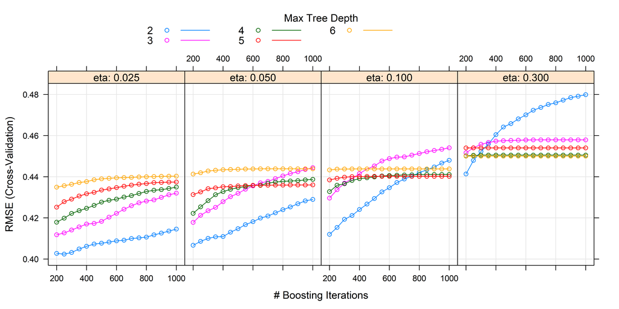

```r
plot(xgb_tune)
```

나머지 parameter에 대해 탐색

```r
tune_grid <- expand.grid(
  nrounds = seq(from = 200, to = nrounds, by = 50),
  eta = c(0.025),
  max_depth = c(2),
  gamma = 0:10,
  colsample_bytree = 1,
  min_child_weight = 1,
  subsample = 1
)

tune_control <- caret::trainControl(
  method = "cv", # cross-validation
  number = 3, # with n folds
  #index = createFolds(tr_treated$Id_clean), # fix the folds
  verboseIter = FALSE, # no training log
  allowParallel = TRUE # FALSE for reproducible results
)

xgb_tune <- caret::train(
  x = input_x,
  y = input_y,
  trControl = tune_control,
  tuneGrid = tune_grid,
  method = "xgbTree",
  verbose = TRUE
)
```

```
## [23:38:45] WARNING: amalgamation/../src/objective/regression_obj.cu:170: reg:linear is now deprecated in favor of reg:squarederror.
```

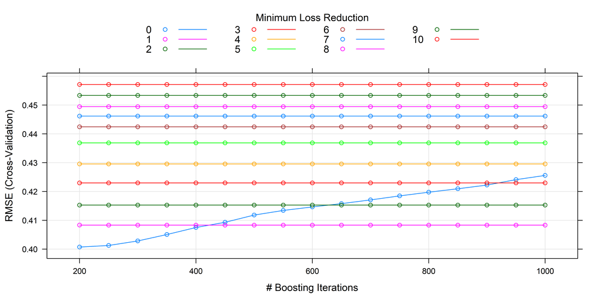

```r
plot(xgb_tune)
```

gamma에 대해서도 탐색

```r
grid_default <- expand.grid(
  nrounds = 200,
  max_depth = 2,
  eta = 0.025,
  gamma = 0,
  colsample_bytree = 1,
  min_child_weight = 1,
  subsample = 1
)

train_control <- caret::trainControl(
  method = "none",
  verboseIter = T, # no training log
  allowParallel = TRUE # FALSE for reproducible results
)

xgb_tune <- caret::train(
  x = input_x,
  y = input_y,
  trControl = train_control,
  tuneGrid = grid_default,
  method = "xgbTree",
  verbose = TRUE
)
```

```
## Fitting nrounds = 200, max_depth = 2, eta = 0.025, gamma = 0, colsample_bytree = 1, min_child_weight = 1, subsample = 1 on full training set
## [23:38:47] WARNING: amalgamation/../src/objective/regression_obj.cu:170: reg:linear is now deprecated in favor of reg:squarederror.
```

parameter결정 후, 모형 적합

```r
result_xg <- ifelse(predict(xgb_tune, test)>0.5, "tested_positive", "tested_negative")

confusionMatrix(result_xg %>% as.factor, test$class %>% as.factor)
```

```
## Confusion Matrix and Statistics
##
##                  Reference
## Prediction        tested_negative tested_positive
##   tested_negative             135              33
##   tested_positive              15              47
##
##                Accuracy : 0.7913
##                  95% CI : (0.733, 0.8419)
##     No Information Rate : 0.6522
##     P-Value [Acc > NIR] : 2.878e-06
##
##                   Kappa : 0.5145
##
##  Mcnemar's Test P-Value : 0.01414
##
##             Sensitivity : 0.9000
##             Specificity : 0.5875
##          Pos Pred Value : 0.8036
##          Neg Pred Value : 0.7581
##              Prevalence : 0.6522
##          Detection Rate : 0.5870
##    Detection Prevalence : 0.7304
##       Balanced Accuracy : 0.7438
##
##        'Positive' Class : tested_negative
##
```

## naive bayes

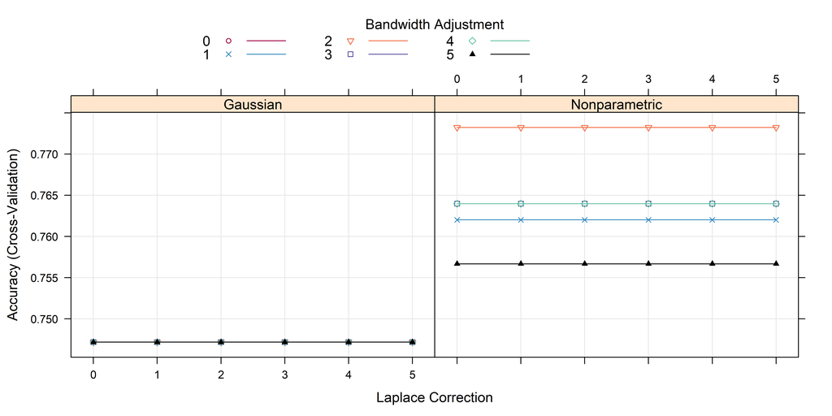

```r
set.seed(100)

train.control <- trainControl(method = "cv", number = 10)

search_grid <- expand.grid(
  usekernel = c(TRUE, FALSE),
  fL = 0:5,
  adjust = seq(0, 5, by = 1)
)


model_cv1 <- train(x=train[, 1:8],
                  y=train$class,
                  method = "nb",
                  trControl = train.control,
                  tuneGrid = search_grid,
                  preProc = c("BoxCox", "center"))

trellis.par.set(caretTheme())
plot(model_cv1)
```

```r
result_nb <- predict(model_cv1, test)

confusionMatrix(result_nb, test$class)
```

```
## Confusion Matrix and Statistics
##
##                  Reference
## Prediction        tested_negative tested_positive
##   tested_negative             120              23
##   tested_positive              30              57
##
##                Accuracy : 0.7696
##                  95% CI : (0.7097, 0.8224)
##     No Information Rate : 0.6522
##     P-Value [Acc > NIR] : 7.748e-05
##
##                   Kappa : 0.5022
##
##  Mcnemar's Test P-Value : 0.4098
##
##             Sensitivity : 0.8000
##             Specificity : 0.7125
##          Pos Pred Value : 0.8392
##          Neg Pred Value : 0.6552
##              Prevalence : 0.6522
##          Detection Rate : 0.5217
##    Detection Prevalence : 0.6217
##       Balanced Accuracy : 0.7563
##
##        'Positive' Class : tested_negative
##
```

## Evaluate Machine Learning Algorithms

| Method | Accuracy Performance |
| --- | --- |
| Logistic Regression | 0.7652174 |
| Decision Tree | 0.7217391 |
| Random Forest | 0.7826087 |
| naive bayes | 0.7695652 |
| XGBOOST | 0.7913043 |

XGBOOST works good with 79.1304348% accuracy.

## F1 score

but, we must think the measure f1 score because data is imbalanced.  
Accuracy works well on balanced data

f1 score is harmonic mean of recall and precision

조화평균은 단순하게 평균을 구하는 것이 아니라, 뭔가 큰 값이 있다면 페널티를 주어, 작은 값 위주로 평균을 구하게 된다.  
이런 원리로, imbalanced data에 대해서 큰 값을 가진 class가 있더라도, 강력한 효과를 통해 평균을 구하게 된다.

$$F1 Score = 2\times {precision\times Recall \over Precision +Recall}$$

Precision = TP / (TP + FP)  
Recall = TP / (TP + FN)

```r
# rf
precision_rf<-
  confusionMatrix(pre, test$class)[[2]][2,2] /
  (confusionMatrix(pre, test$class)[[2]][2,2] + confusionMatrix(pre, test$class)[[2]][1,2])

recall_rf <-
  confusionMatrix(pre, test$class)[[2]][2,2] /
  (confusionMatrix(pre, test$class)[[2]][2,2] + confusionMatrix(pre, test$class)[[2]][2,1])


f1_rf <- 2*((precision_rf*recall_rf)/(precision_rf+recall_rf))

# xgboost
precision_xg<-
  confusionMatrix(result_xg %>% as.factor, test$class %>% as.factor)[[2]][2,2]/
  (confusionMatrix(result_xg %>% as.factor, test$class %>% as.factor)
[[2]][2,2] + confusionMatrix(result_xg %>% as.factor, test$class %>% as.factor)
[[2]][1,2])

recall_xg <-
  confusionMatrix(result_xg %>% as.factor, test$class %>% as.factor)[[2]][2,2]/
  (confusionMatrix(result_xg %>% as.factor, test$class %>% as.factor)
[[2]][2,2] + confusionMatrix(result_xg %>% as.factor, test$class %>% as.factor)
[[2]][2,1])


f1_xg <- 2*((precision_xg*recall_xg)/(precision_xg+recall_xg))




# naive bayes
precision_nb<-
  confusionMatrix(result_nb, test$class)[[2]][2,2] /
  (confusionMatrix(result_nb, test$class)[[2]][2,2] + confusionMatrix(result_nb, test$class)[[2]][1,2])

recall_nb <-
  confusionMatrix(result_nb, test$class)[[2]][2,2] /
  (confusionMatrix(result_nb, test$class)[[2]][2,2] + confusionMatrix(result_nb, test$class)[[2]][2,1])


f1_nb <- 2*((precision_nb*recall_nb)/(precision_nb+recall_nb))
```

#### Comparison

```r
data.frame(f1_rf, f1_xg, f1_nb)
```

```
##       f1_rf     f1_xg     f1_nb
## 1 0.6478873 0.6619718 0.6826347
```

nb가 accuracy는 조금 더 낮을지 몰라도 tested_positive를 조금 더 세밀하게 분류하여 전반적인 모형의 성능이 좋게 나온듯 싶다.

다음에 시간이 나면, 더 나은 방법이 있는지 업데이트 할 예정이다.